# Exercise solutions: Section 2.10

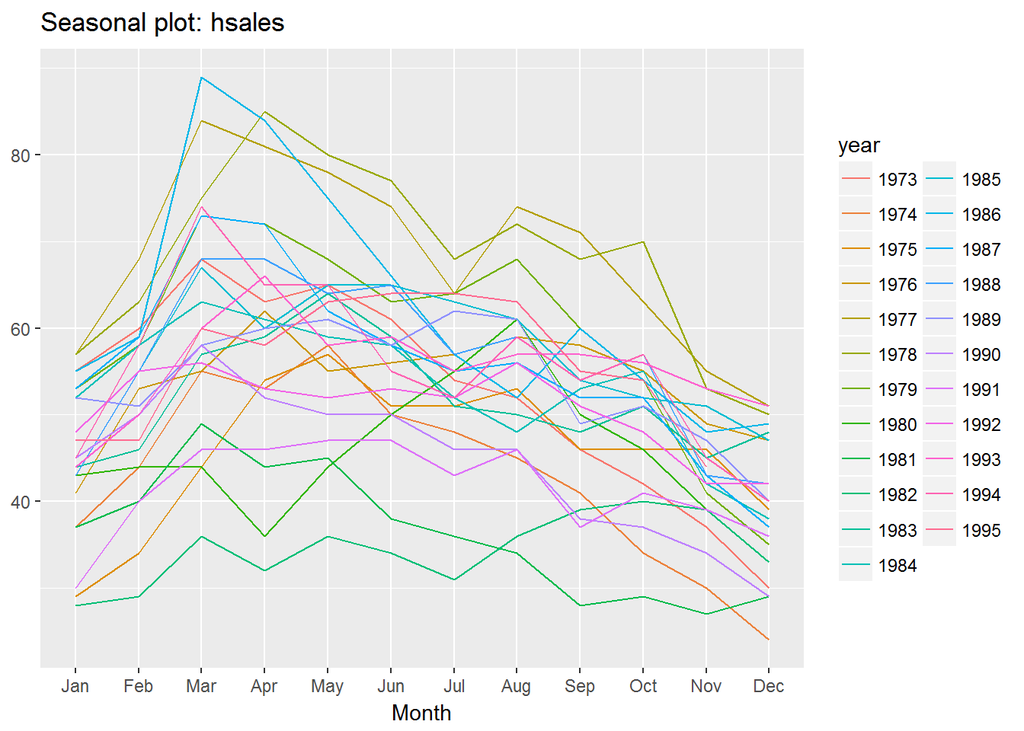

```r
ggseasonplot(hsales)
```

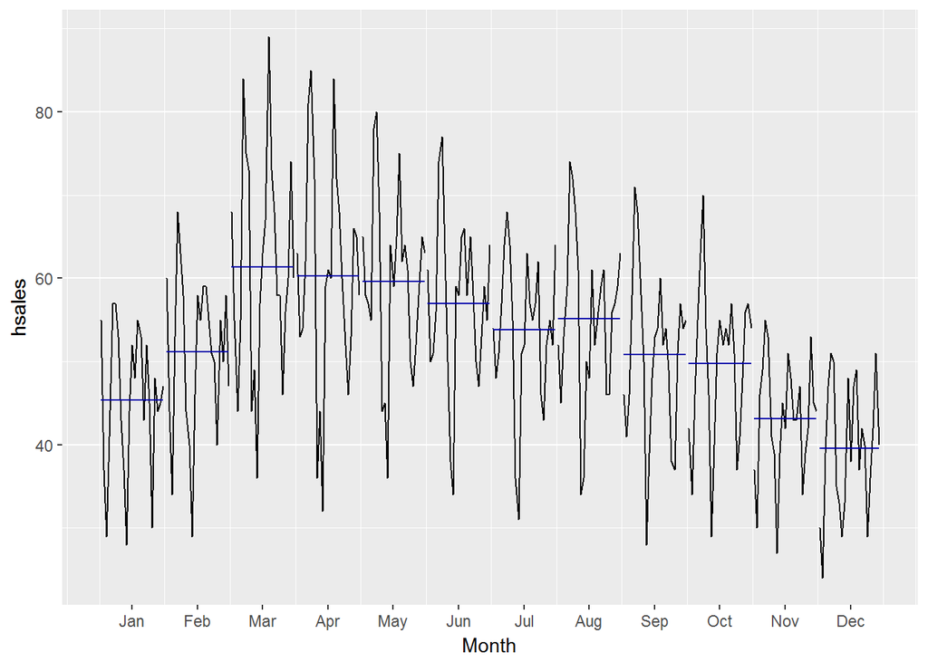

```r
ggsubseriesplot(hsales)
```

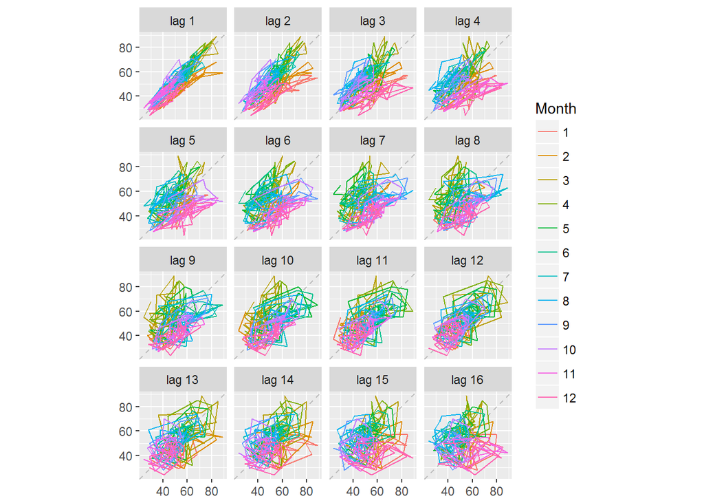

```r
gglagplot(hsales)
```

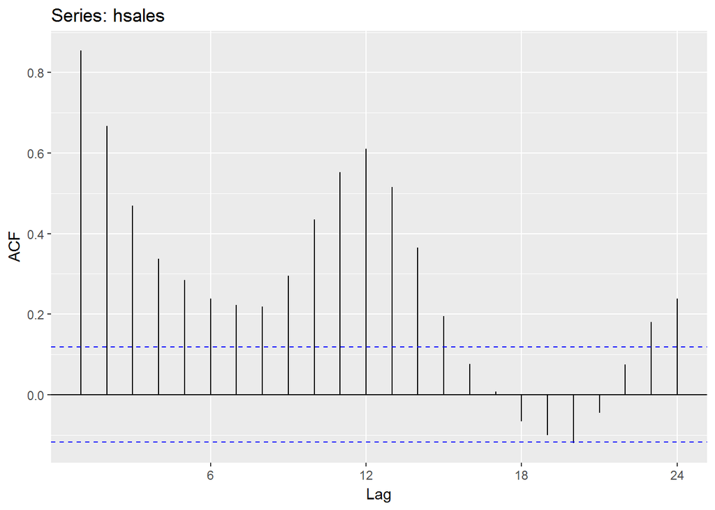

```r
ggAcf(hsales)
```

- Seasonality evident in all plots
- Cyclicity seen in first two plots
- No trend
- ACF only shows seasonality. Cycle length too long to show up here.

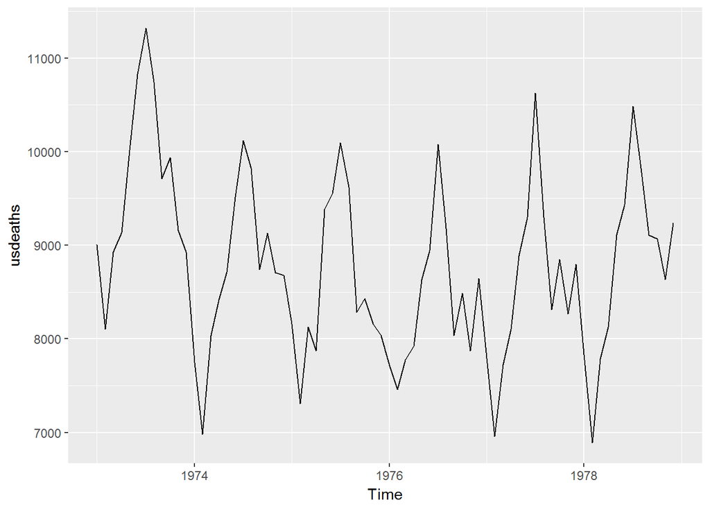

```r
autoplot(usdeaths)
```

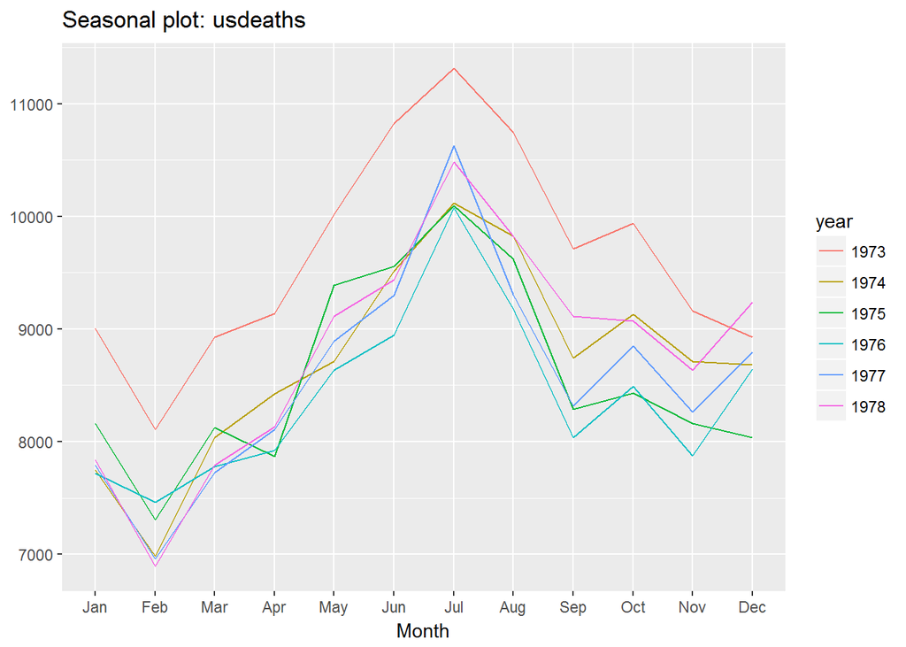

```r
ggseasonplot(usdeaths)
```

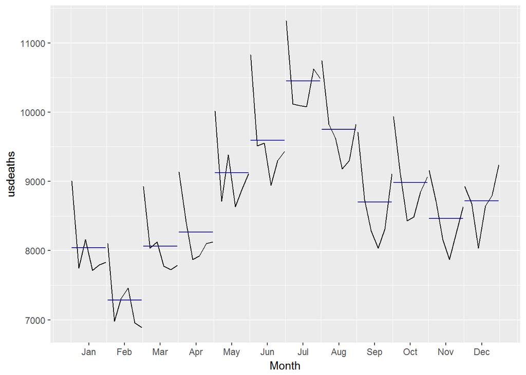

```r
ggsubseriesplot(usdeaths)
```

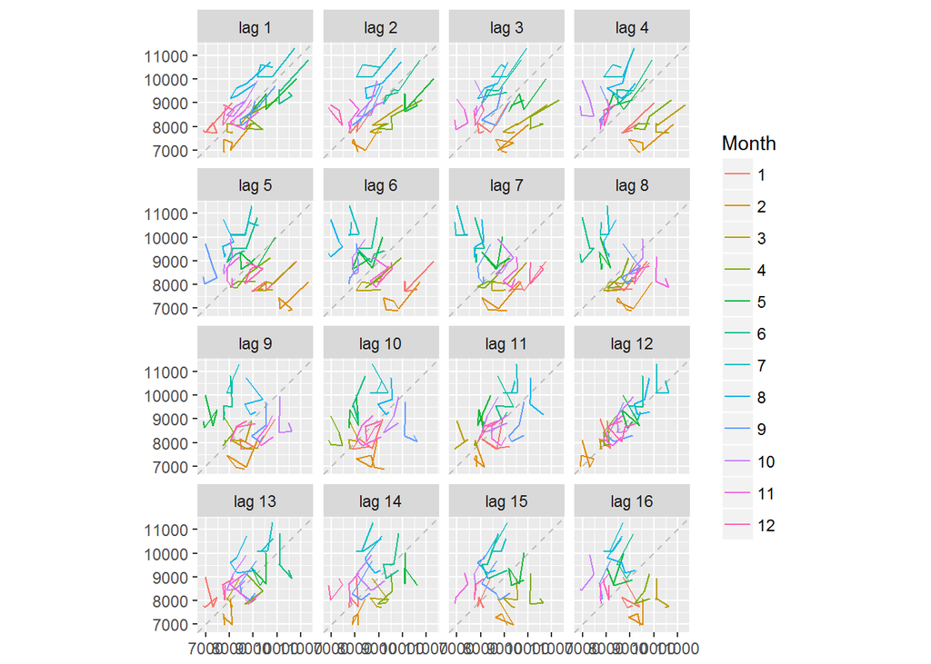

```r
gglagplot(usdeaths)
```

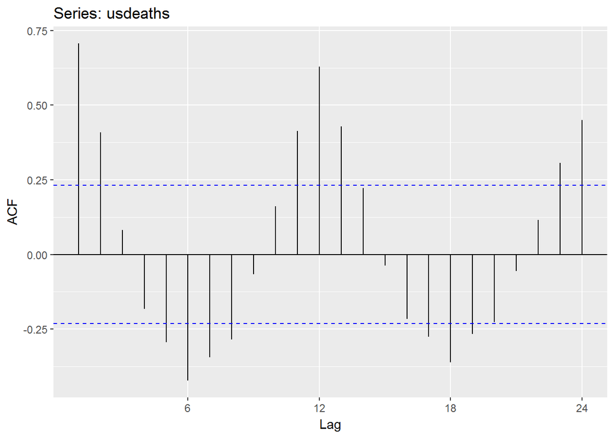

```r
ggAcf(usdeaths)
```

- Seasonality evident in all plots
- No cyclicity or trend

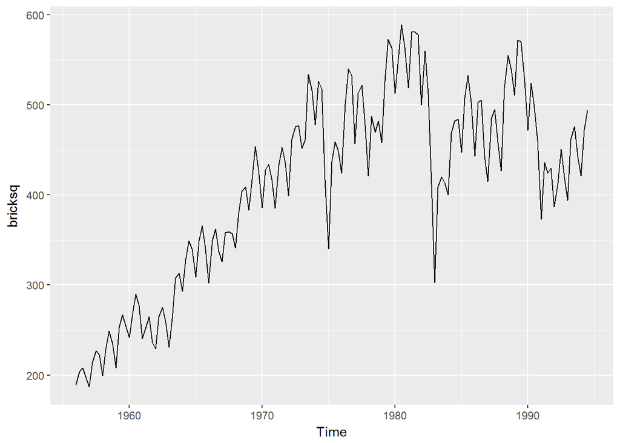

```r
autoplot(bricksq)
```

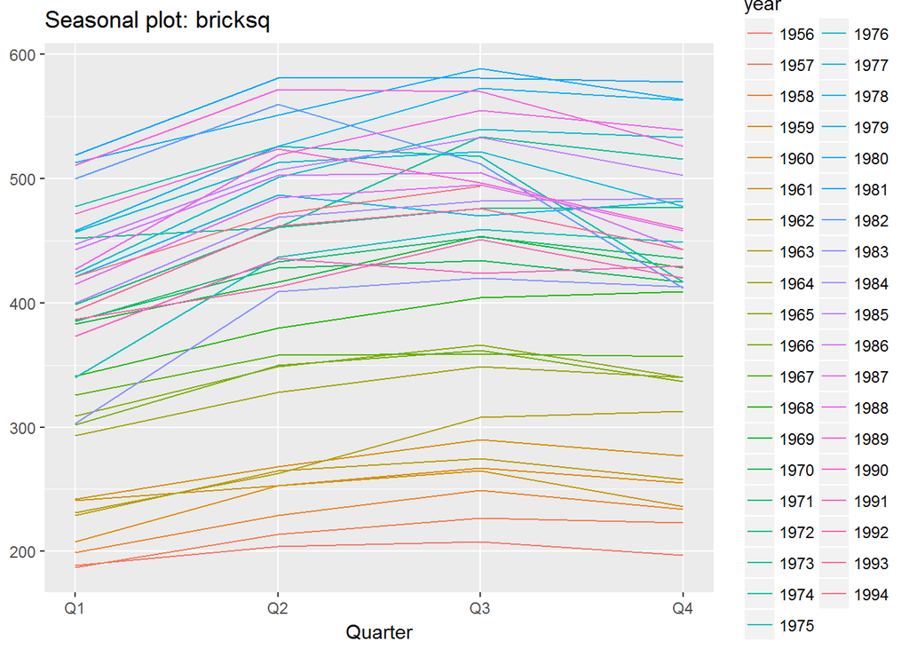

```r
ggseasonplot(bricksq)
```

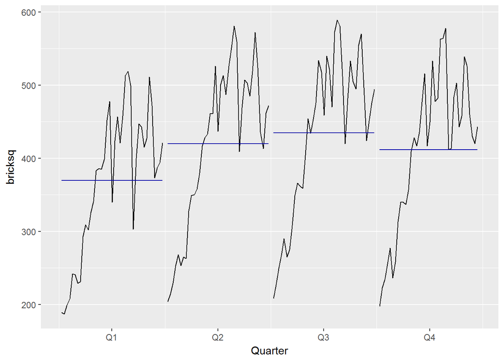

```r
ggsubseriesplot(bricksq)
```

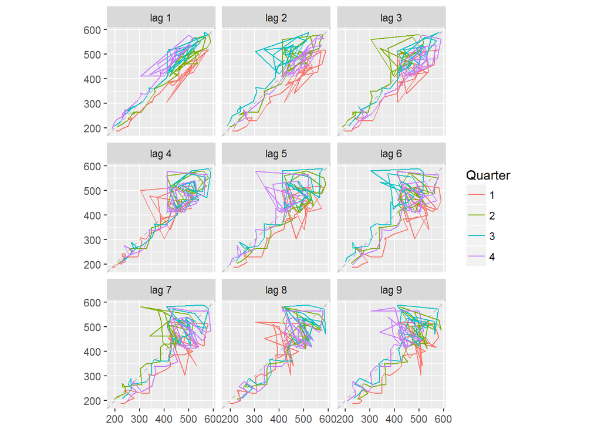

```r
gglagplot(bricksq)
```

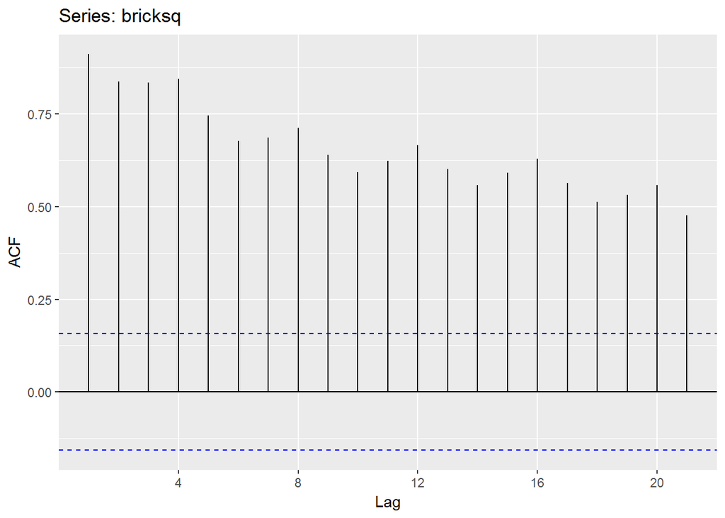

```r
ggAcf(bricksq)
```

- Q1 is the lowest and Q3 is the highest.
- 1982 and 1983 are unusual, especially the last quarter of 1982 and the first quarter of 1983. This was a recession.
- Seasonality weak compared to trend
- Cyclicity slightly evident in time plot and subseries plot
- positive relationships in lag plot dominated by the strong trend + ACF only shows seasonality and trend. Cycle length too long to show up here.

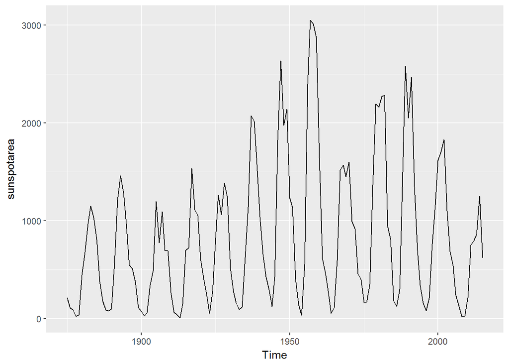

```r
autoplot(sunspotarea)
```

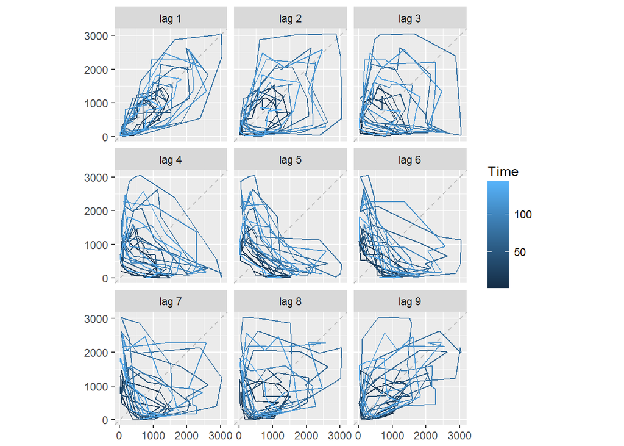

```r
#ggseasonplot(sunspotarea)
#ggsubseriesplot(sunspotarea)
gglagplot(sunspotarea)
```

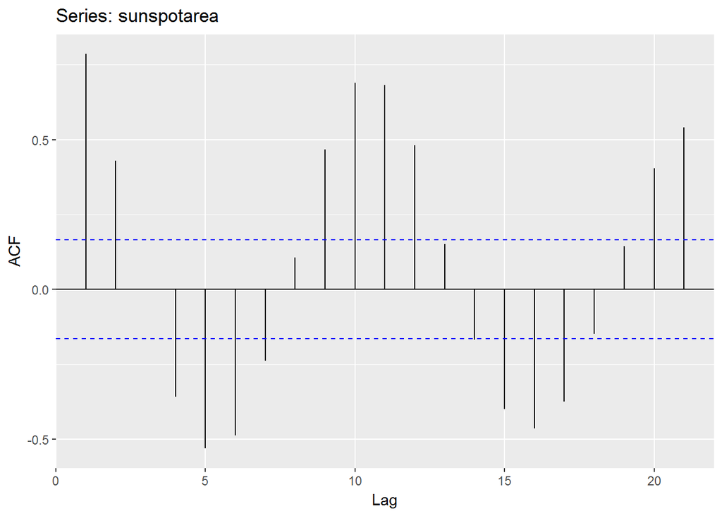

```r
ggAcf(sunspotarea)
```

- Data is not seasonal data hence we don’t run commands for seasonal features.
- Cyclicity seen in all plots (cycle length around 10-11)

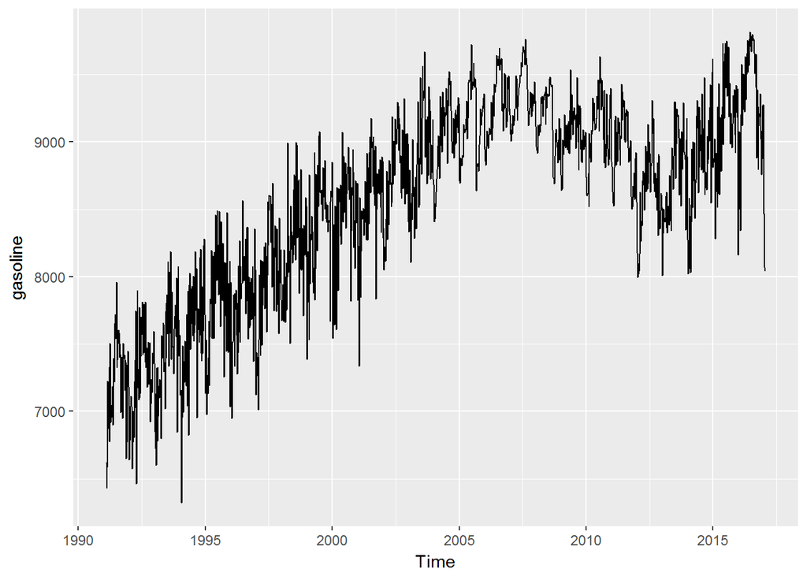

```r
autoplot(gasoline)
```

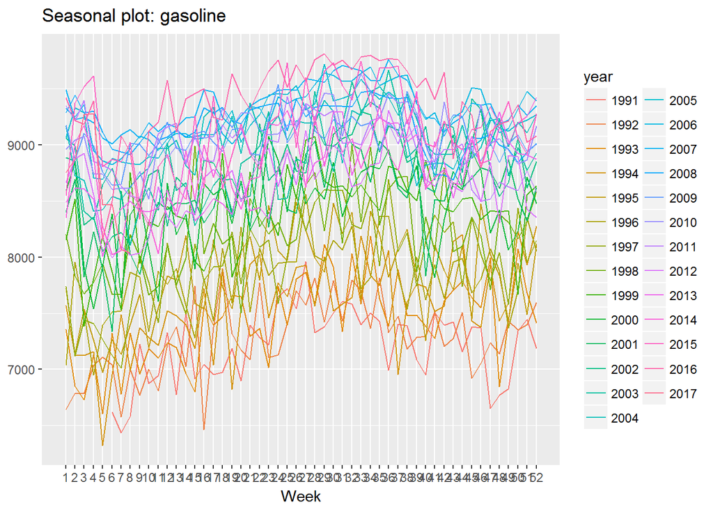

```r
ggseasonplot(gasoline)
```

```
## geom_path: Each group consists of only one observation. Do you need to
## adjust the group aesthetic?
## geom_path: Each group consists of only one observation. Do you need to
## adjust the group aesthetic?
```

[figure not shown]

```r
ggsubseriesplot(gasoline)
```

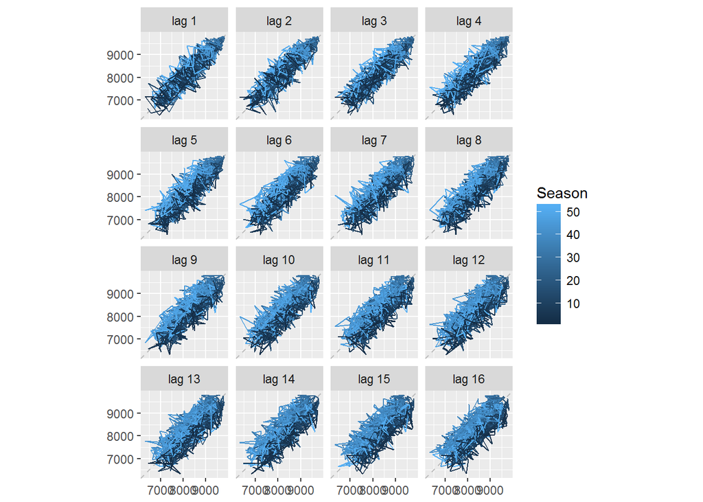

```r
gglagplot(gasoline)
```

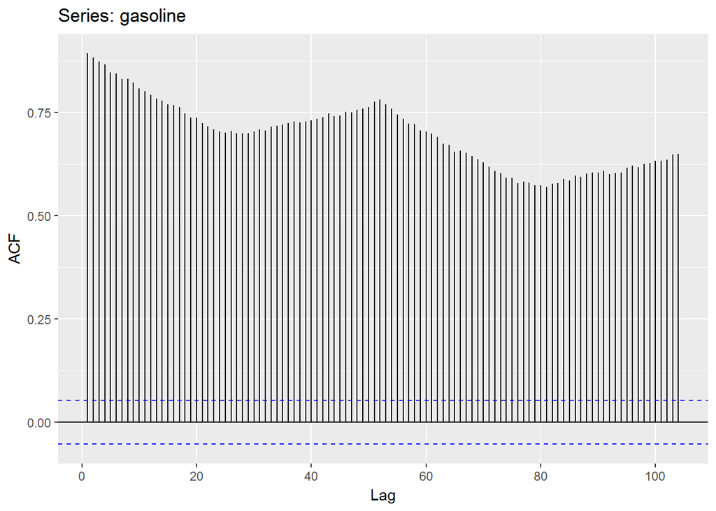

```r
ggAcf(gasoline)
```

- Seasonality clear in seasonal plot
- Non-integer seasonality makes the subseries plot fail
- Seasonal length too long for the lagplot to be useful
- ACF plot shows the seasonality and trend clearly
7. The `arrivals` data set comprises quarterly international arrivals (in thousands) to Australia from Japan, New Zealand, UK and the US.
   - Use `autoplot`, `ggseasonplot` and `ggsubseriesplot` to compare the differences between the arrivals from these four countries.
   - Can you identify any unusual observations?

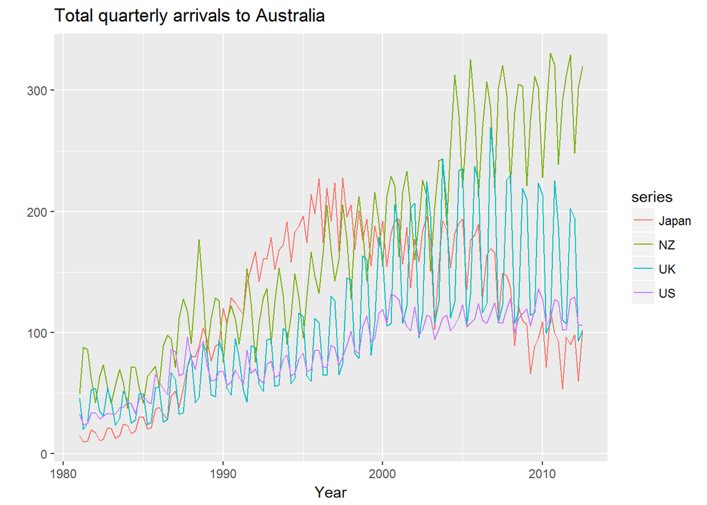

[figure not shown]

[figure not shown]

```r
autoplot(arrivals) +
   xlab("Year") + ylab("") +
   ggtitle("Total quarterly arrivals to Australia")
```

- The time plots show: a decrease in arrivals from Japan since mid-1990s, an increase in arrivals from NZ, a downturn of arrivals from the UK since mid-2000s and a flattening out of the arrivals from the US.

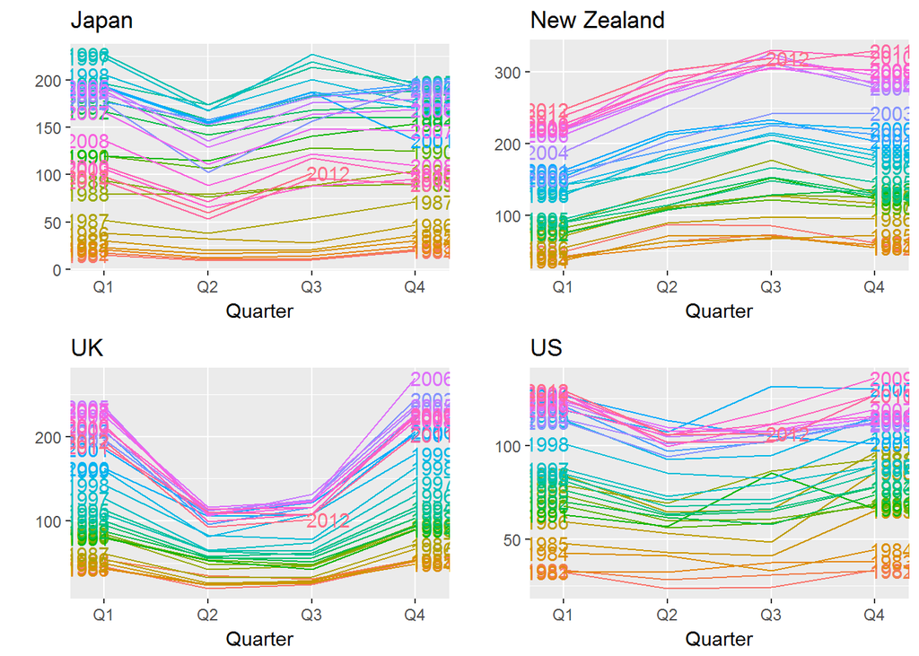

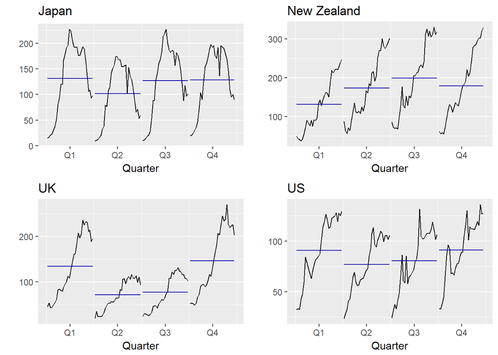

- The seasonal plots show the difference in seasonal patterns from the four source countries. The peaks for from UK and the US happen in Q1 and Q4 which include the summer period in Australia, Christmas and New Year’s holiday period with Q2 and Q3 being the troughs. For Japan peaks occur mostly in Q1 but also Q3 reflecting both peak arrivals in summer but also winter which possibly correspond to winter skying season or visiting northern Australia in during the dry season. The one source country that is very different is New Zealand. Peak arrivals from New Zealand occur during the Q3 followed by Q2 and Q4. Unlike all other source countries, the trough clearly occurs during Q1 the January (summer) quarter. The seasonal plots are also useful, revealing anomalies or one-off events. For example, in the US plot, the peak arrivals for all July quarters occurred in 2000 during the Sydney Olympic games.
- UK is most seasonal
- 2001:Q3-Q4 are unusual for US (9/11 effect)
- 1991:Q3 is unusual for US (Gulf war effect?)
8. The following time plots and ACF plots correspond to four different time series. Your task is to match each time plot in the first row with one of the ACF plots in the second row.

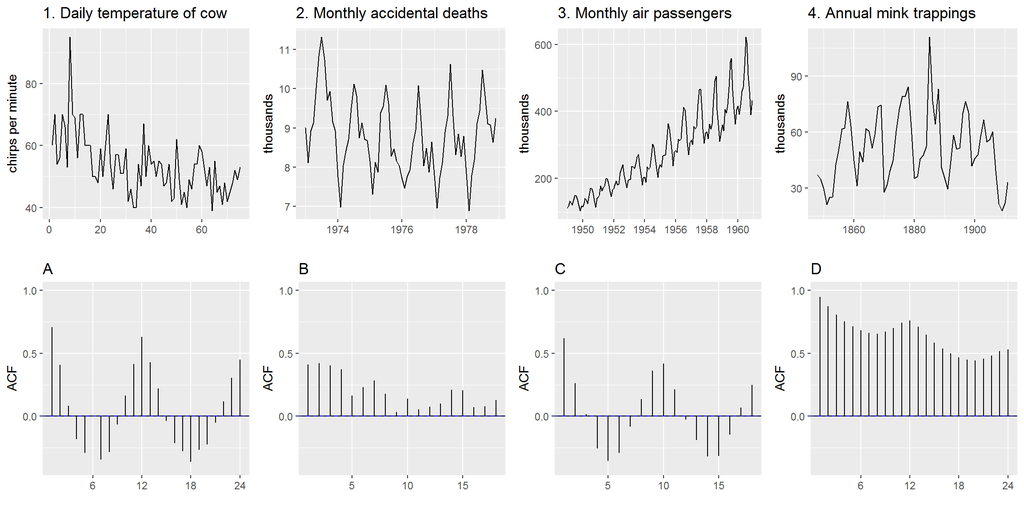

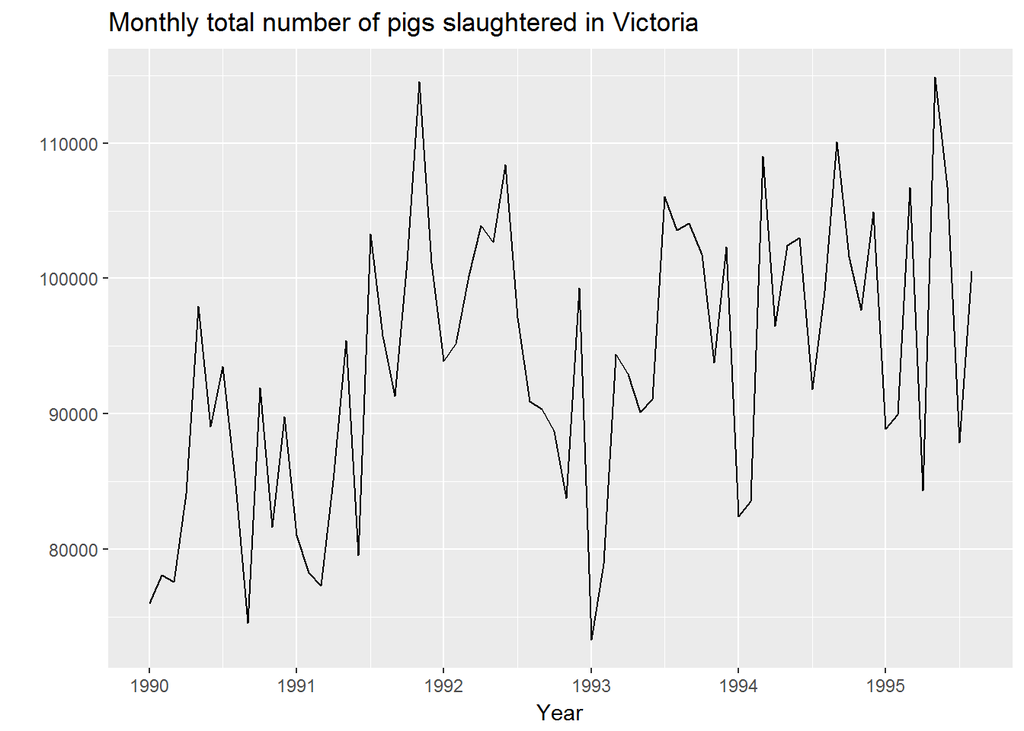

```r
mypigs <- window(pigs, start=1990)
autoplot(mypigs) +
   xlab("Year") + ylab("") +
   ggtitle("Monthly total number of pigs slaughtered in Victoria")
```

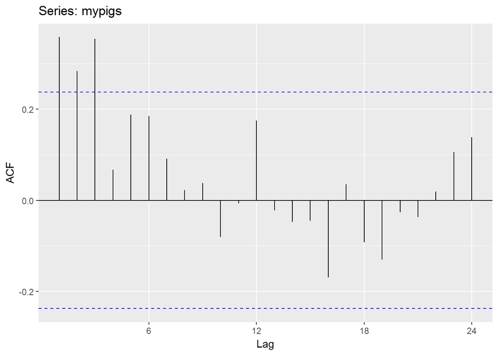

```r
ggAcf(mypigs)
```

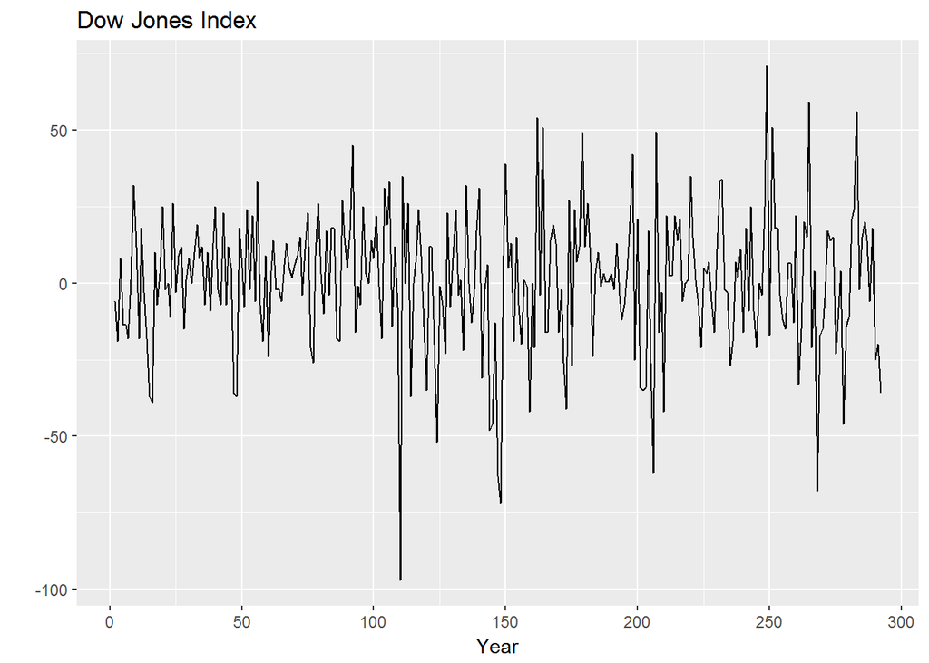

```r
ddj<-diff(dj)
autoplot(ddj) +
   xlab("Year") + ylab("") +
   ggtitle("Dow Jones Index")
```

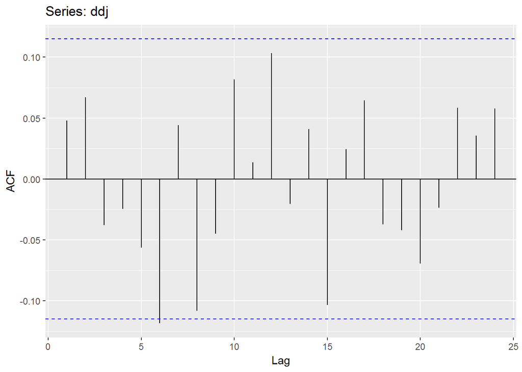

```r
ggAcf(ddj)
```